# Clase 15. VAR(p)

Series de Tiempo | Semestre 2027-I | FC-UNAM

Benjamin Oliva & Omar Alfaro-Rivera

julio 2026

## ¿Qué aprenderemos hoy?

Generalizamos el AR univariado al caso multivariado con los Vectores Autorregresivos (VAR). El VAR(p) modela simultáneamente la dinámica de un sistema de variables, capturando sus interdependencias temporales sin imponer restricciones de causalidad a priori.

Al terminar esta clase deberás poder:

1. Especificar y estimar un VAR(p) con `VAR()` del paquete `vars`
2. Seleccionar el orden p usando los criterios AIC, BIC, HQ y FPE con `VARselect()`
3. Verificar la estabilidad del sistema comprobando que todas las raíces del polinomio característico tienen módulo menor que 1

**Datos:** `Datos_Ad.RData` — INPC, TC, CETE28 e IGAE ajustados por estacionalidad (de Clase_11)

# Importamos Datos desde un archivo de R:

Los datos “cargados” son los originales y los ajustados por estacionalidad. Los cuales son:

- INPC: Indice Nacional de Precios al Consumidor (2QJul2018 = 100)
- TC: Tipo de Cambio FIX
- CETE28: Tasa de rendimiento promedio mensual de los Cetes 28, en por ciento anual
- IGAE: Indicador global de la actividad económica (2013 = 100)
- IPI: Industrial Production Index (2012 = 100)

```
##        FECHA     INPC     TC CETE28    IGAE     IPI  INPC_Ad  TC_Ad CETE28_Ad
## 1 2000-01-01 44.93083 9.4878  16.19 71.9852 90.7125 44.76314 9.4878     16.19
## 2 2000-02-01 45.32938 9.4252  15.81 72.2534 91.4934 45.17539 9.4252     15.81
## 3 2000-03-01 45.58068 9.2876  13.66 74.6511 93.1033 45.39320 9.2876     13.66
## 4 2000-04-01 45.84002 9.3903  12.93 71.3747 91.8422 45.70325 9.3903     12.93
## 5 2000-05-01 46.01138 9.5158  14.18 75.4207 92.1629 46.09141 9.5158     14.18
## 6 2000-06-01 46.28392 9.8295  15.65 74.9497 95.1094 46.43430 9.8295     15.65
##    IGAE_Ad   IPI_Ad
## 1 74.19995 91.61798
## 2 73.85998 91.76105
## 3 73.59885 92.39186
## 4 73.73813 92.93440
## 5 73.98389 92.75686
## 6 73.80197 92.97452
```

## Conversion a series de tiempo:

```r
DLINPC <- ts(log(Datos_Ad$INPC_Ad) - lag(log(Datos_Ad$INPC_Ad), 1),
             start = c(2000, 1),
             freq = 12)

DLTC <- ts(log(Datos_Ad$TC_Ad) - lag(log(Datos_Ad$TC_Ad), 1),
           start = c(2000, 1),
           freq = 12)

DCETE28 <- ts(Datos_Ad$CETE28_Ad - lag(Datos_Ad$CETE28_Ad, 1),
               start = c(2000, 1),
               freq = 12)

DLIGAE <- ts(log(Datos_Ad$IGAE_Ad) - lag(log(Datos_Ad$IGAE_Ad), 1),
             start = c(2000, 1),
             freq = 12)

DLIPI <- ts(log(Datos_Ad$IPI_Ad) - lag(log(Datos_Ad$IPI_Ad), 1),
            start = c(2000, 1),
            freq = 12)
```

# Combinacion en un solo set de datos (Dos formas)

### 1

```r
Datos <- data.frame(cbind(DLINPC, DLTC, DCETE28, DLIGAE, DLIPI))
```

### 2

```r
Datos <- ts(Datos[2 : 282, ],
            start = c(2000, 2), freq = 12)
```

## Graficas:

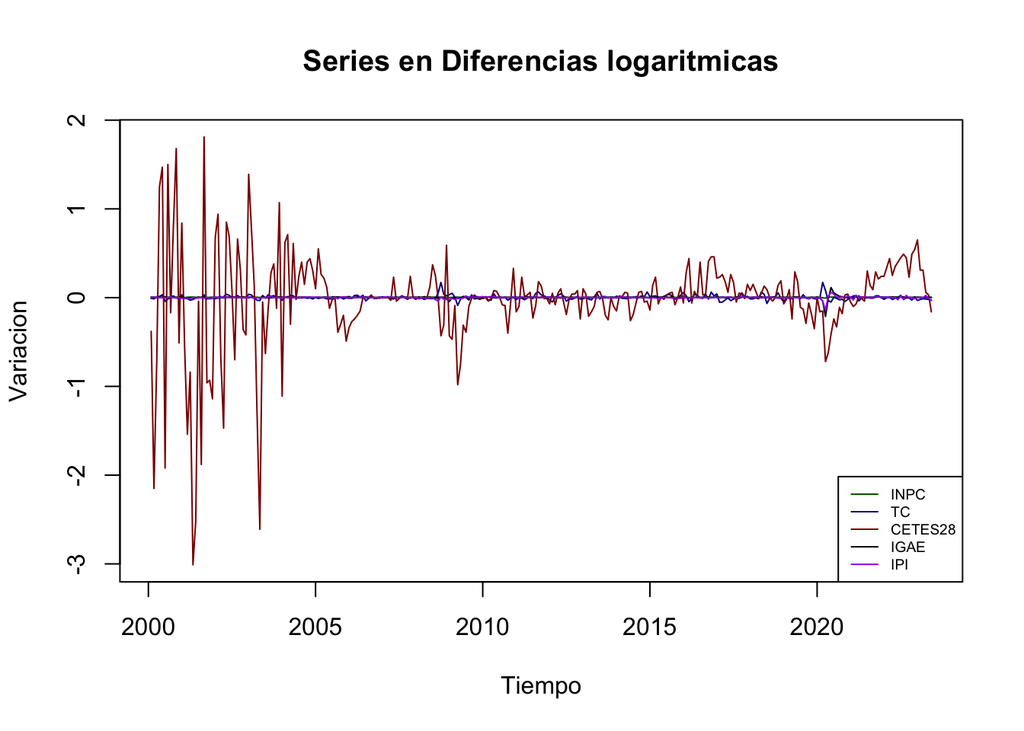

```r
plot(Datos, plot.type = "s",
     col = c("darkgreen", "darkblue", "darkred", "black", "purple"),
     main = "Series en Diferencias logaritmicas",
     xlab = "Tiempo", ylab = "Variacion")

legend("bottomright", c("INPC", "TC", "CETES28", "IGAE", "IPI"),
       cex = 0.6, lty = 1:1,
       col = c("darkgreen", "darkblue", "darkred", "black", "purple"))
```

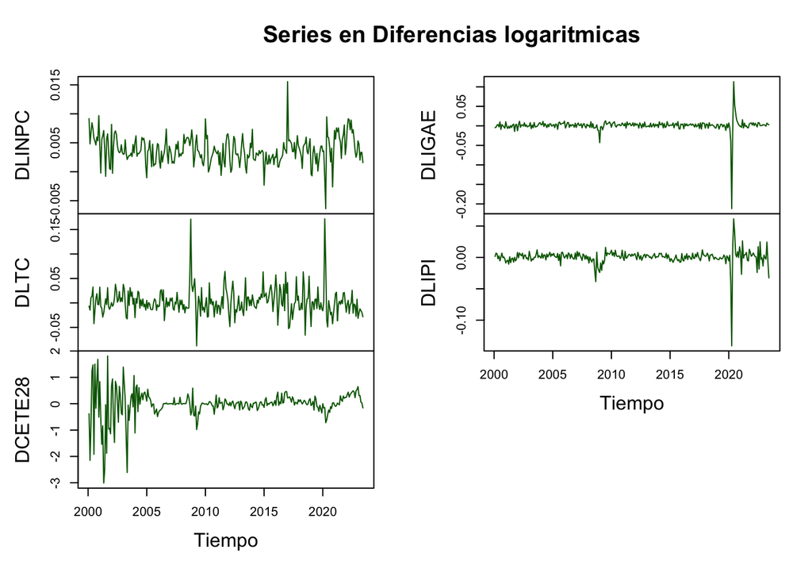

```r
#
plot(Datos, plot.type = "m",
     col = "darkgreen",
     main = "Series en Diferencias logaritmicas", xlab = "Tiempo")
```

## Implementación del VAR(p)

```r
# 1. VAR(p):
# ARGUMENTOS:
# function (y, p = 1,
# type = c("const", "trend", "both", "none"),
# season = NULL, exogen = NULL, lag.max = NULL,
# ic = c("AIC", "HQ", "SC", "FPE"))

?VAR
```

### p = 1

```r
VAR(Datos, p = 1)
```

```
##
## VAR Estimation Results:
## =======================
##
## Estimated coefficients for equation DLINPC:
## ===========================================
## Call:
## DLINPC = DLINPC.l1 + DLTC.l1 + DCETE28.l1 + DLIGAE.l1 + DLIPI.l1 + const
##
##     DLINPC.l1       DLTC.l1    DCETE28.l1     DLIGAE.l1      DLIPI.l1
##  0.3931187588 -0.0026390727  0.0001582739 -0.0310710110  0.0111898360
##         const
##  0.0022996833
##
##
## Estimated coefficients for equation DLTC:
## =========================================
## Call:
## DLTC = DLINPC.l1 + DLTC.l1 + DCETE28.l1 + DLIGAE.l1 + DLIPI.l1 + const
##
##    DLINPC.l1      DLTC.l1   DCETE28.l1    DLIGAE.l1     DLIPI.l1        const
## -1.464277056  0.278243022 -0.004267701  0.409364870 -0.438718797  0.006695596
##
##
## Estimated coefficients for equation DCETE28:
## ============================================
## Call:
## DCETE28 = DLINPC.l1 + DLTC.l1 + DCETE28.l1 + DLIGAE.l1 + DLIPI.l1 + const
##
##   DLINPC.l1     DLTC.l1  DCETE28.l1   DLIGAE.l1    DLIPI.l1       const
## 17.51828237  0.57462342  0.16564507 -1.57921412  6.01834310 -0.08188295
##
##
## Estimated coefficients for equation DLIGAE:
## ===========================================
## Call:
## DLIGAE = DLINPC.l1 + DLTC.l1 + DCETE28.l1 + DLIGAE.l1 + DLIPI.l1 + const
##
##     DLINPC.l1       DLTC.l1    DCETE28.l1     DLIGAE.l1      DLIPI.l1
##  0.6530410115 -0.1927645354  0.0002673710 -0.1400723490  0.4773367809
##         const
## -0.0008751141
##
##
## Estimated coefficients for equation DLIPI:
## ==========================================
## Call:
## DLIPI = DLINPC.l1 + DLTC.l1 + DCETE28.l1 + DLIGAE.l1 + DLIPI.l1 + const
##
##     DLINPC.l1       DLTC.l1    DCETE28.l1     DLIGAE.l1      DLIPI.l1
##  0.0124656778 -0.1451149301  0.0010852826 -0.0142700890  0.1230144942
##         const
##  0.0005870703
```

```r
VAR(Datos[ , 1:3], p = 1)
```

```
##
## VAR Estimation Results:
## =======================
##
## Estimated coefficients for equation DLINPC:
## ===========================================
## Call:
## DLINPC = DLINPC.l1 + DLTC.l1 + DCETE28.l1 + const
##
##    DLINPC.l1      DLTC.l1   DCETE28.l1        const
## 3.622558e-01 4.719195e-04 9.201656e-05 2.376428e-03
##
##
## Estimated coefficients for equation DLTC:
## =========================================
## Call:
## DLTC = DLINPC.l1 + DLTC.l1 + DCETE28.l1 + const
##
##   DLINPC.l1     DLTC.l1  DCETE28.l1       const
## -1.38928570  0.26600052 -0.00405761  0.00672666
##
##
## Estimated coefficients for equation DCETE28:
## ============================================
## Call:
## DCETE28 = DLINPC.l1 + DLTC.l1 + DCETE28.l1 + const
##
##   DLINPC.l1     DLTC.l1  DCETE28.l1       const
## 22.15397517  0.19496321  0.17467853 -0.09747997
```

```r
VAR(Datos[ , c(1, 2, 3, 4)], p = 1, exogen = Datos[ , 5])
```

```
##
## VAR Estimation Results:
## =======================
##
## Estimated coefficients for equation DLINPC:
## ===========================================
## Call:
## DLINPC = DLINPC.l1 + DLTC.l1 + DCETE28.l1 + DLIGAE.l1 + const + exo1
##
##     DLINPC.l1       DLTC.l1    DCETE28.l1     DLIGAE.l1         const
##  0.3938930205  0.0050441788  0.0001026455 -0.0275999727  0.0022619538
##          exo1
##  0.0535454696
##
##
## Estimated coefficients for equation DLTC:
## =========================================
## Call:
## DLTC = DLINPC.l1 + DLTC.l1 + DCETE28.l1 + DLIGAE.l1 + const + exo1
##
##    DLINPC.l1      DLTC.l1   DCETE28.l1    DLIGAE.l1        const         exo1
## -1.586335876  0.242135453 -0.004157618  0.168848376  0.007421674 -0.301134971
##
##
## Estimated coefficients for equation DCETE28:
## ============================================
## Call:
## DCETE28 = DLINPC.l1 + DLTC.l1 + DCETE28.l1 + DLIGAE.l1 + const + exo1
##
##   DLINPC.l1     DLTC.l1  DCETE28.l1   DLIGAE.l1       const        exo1
## 19.21329322  1.01036437  0.16460035  1.74365853 -0.09167402  3.72685428
##
##
## Estimated coefficients for equation DLIGAE:
## ===========================================
## Call:
## DLIGAE = DLINPC.l1 + DLTC.l1 + DCETE28.l1 + DLIGAE.l1 + const + exo1
##
##     DLINPC.l1       DLTC.l1    DCETE28.l1     DLIGAE.l1         const
##  0.7524609407 -0.0569619421 -0.0006062976  0.0835999062 -0.0019392897
##          exo1
##  0.9822593217
```

### p = 2

```r
VAR(Datos, p = 2)
```

```
##
## VAR Estimation Results:
## =======================
##
## Estimated coefficients for equation DLINPC:
## ===========================================
## Call:
## DLINPC = DLINPC.l1 + DLTC.l1 + DCETE28.l1 + DLIGAE.l1 + DLIPI.l1 + DLINPC.l2 + DLTC.l2 + DCETE28.l2 + DLIGAE.l2 + DLIPI.l2 + const
##
##     DLINPC.l1       DLTC.l1    DCETE28.l1     DLIGAE.l1      DLIPI.l1
##  0.3886792073 -0.0047924109  0.0001425897 -0.0225475183  0.0102477924
##     DLINPC.l2       DLTC.l2    DCETE28.l2     DLIGAE.l2      DLIPI.l2
## -0.0049915855  0.0101013430  0.0001221844  0.0065539367 -0.0144184608
##         const
##  0.0023123801
##
##
## Estimated coefficients for equation DLTC:
## =========================================
## Call:
## DLTC = DLINPC.l1 + DLTC.l1 + DCETE28.l1 + DLIGAE.l1 + DLIPI.l1 + DLINPC.l2 + DLTC.l2 + DCETE28.l2 + DLIGAE.l2 + DLIPI.l2 + const
##
##    DLINPC.l1      DLTC.l1   DCETE28.l1    DLIGAE.l1     DLIPI.l1    DLINPC.l2
## -1.330336314  0.309908510 -0.004360347  0.379862454 -0.524924857  0.054689505
##      DLTC.l2   DCETE28.l2    DLIGAE.l2     DLIPI.l2        const
## -0.181638774  0.002765408  0.081116332 -0.177282770  0.006465271
##
##
## Estimated coefficients for equation DCETE28:
## ============================================
## Call:
## DCETE28 = DLINPC.l1 + DLTC.l1 + DCETE28.l1 + DLIGAE.l1 + DLIPI.l1 + DLINPC.l2 + DLTC.l2 + DCETE28.l2 + DLIGAE.l2 + DLIPI.l2 + const
##
##    DLINPC.l1      DLTC.l1   DCETE28.l1    DLIGAE.l1     DLIPI.l1    DLINPC.l2
##  34.83976633   0.68956046   0.12583466  -4.16546968   7.68390644 -24.33707082
##      DLTC.l2   DCETE28.l2    DLIGAE.l2     DLIPI.l2        const
##   0.49920272   0.08932024  -4.34726674  11.87014149  -0.04600741
##
##
## Estimated coefficients for equation DLIGAE:
## ===========================================
## Call:
## DLIGAE = DLINPC.l1 + DLTC.l1 + DCETE28.l1 + DLIGAE.l1 + DLIPI.l1 + DLINPC.l2 + DLTC.l2 + DCETE28.l2 + DLIGAE.l2 + DLIPI.l2 + const
##
##    DLINPC.l1      DLTC.l1   DCETE28.l1    DLIGAE.l1     DLIPI.l1    DLINPC.l2
##  0.709954444 -0.219254331  0.001456901  0.039330177  0.388054257 -0.752489972
##      DLTC.l2   DCETE28.l2    DLIGAE.l2     DLIPI.l2        const
##  0.072018564 -0.001271551 -0.143456689 -0.159086963  0.001746940
##
##
## Estimated coefficients for equation DLIPI:
## ==========================================
## Call:
## DLIPI = DLINPC.l1 + DLTC.l1 + DCETE28.l1 + DLIGAE.l1 + DLIPI.l1 + DLINPC.l2 + DLTC.l2 + DCETE28.l2 + DLIGAE.l2 + DLIPI.l2 + const
##
##    DLINPC.l1      DLTC.l1   DCETE28.l1    DLIGAE.l1     DLIPI.l1    DLINPC.l2
##  0.032571204 -0.164848831  0.002070029  0.099861370  0.067325206 -0.538809955
##      DLTC.l2   DCETE28.l2    DLIGAE.l2     DLIPI.l2        const
##  0.052361056 -0.001765469 -0.089266620 -0.086230504  0.002465622
```

### p = 3

```r
VAR(Datos, p = 3)
```

```
##
## VAR Estimation Results:
## =======================
##
## Estimated coefficients for equation DLINPC:
## ===========================================
## Call:
## DLINPC = DLINPC.l1 + DLTC.l1 + DCETE28.l1 + DLIGAE.l1 + DLIPI.l1 + DLINPC.l2 + DLTC.l2 + DCETE28.l2 + DLIGAE.l2 + DLIPI.l2 + DLINPC.l3 + DLTC.l3 + DCETE28.l3 + DLIGAE.l3 + DLIPI.l3 + const
##
##     DLINPC.l1       DLTC.l1    DCETE28.l1     DLIGAE.l1      DLIPI.l1
##  0.4133744155 -0.0069147253  0.0003149159 -0.0215834291  0.0033087375
##     DLINPC.l2       DLTC.l2    DCETE28.l2     DLIGAE.l2      DLIPI.l2
## -0.0654019912  0.0131489100  0.0001434558  0.0054128828 -0.0147620348
##     DLINPC.l3       DLTC.l3    DCETE28.l3     DLIGAE.l3      DLIPI.l3
##  0.0595692333 -0.0107357533 -0.0001574217 -0.0330696472  0.0187093603
##         const
##  0.0022674012
##
##
## Estimated coefficients for equation DLTC:
## =========================================
## Call:
## DLTC = DLINPC.l1 + DLTC.l1 + DCETE28.l1 + DLIGAE.l1 + DLIPI.l1 + DLINPC.l2 + DLTC.l2 + DCETE28.l2 + DLIGAE.l2 + DLIPI.l2 + DLINPC.l3 + DLTC.l3 + DCETE28.l3 + DLIGAE.l3 + DLIPI.l3 + const
##
##    DLINPC.l1      DLTC.l1   DCETE28.l1    DLIGAE.l1     DLIPI.l1    DLINPC.l2
## -1.237582442  0.303031789 -0.003141684  0.364019957 -0.558390456 -0.074053963
##      DLTC.l2   DCETE28.l2    DLIGAE.l2     DLIPI.l2    DLINPC.l3      DLTC.l3
## -0.196322744  0.003623054  0.131951291 -0.211459025 -0.006657112 -0.004424657
##   DCETE28.l3    DLIGAE.l3     DLIPI.l3        const
## -0.003322587  0.006690597 -0.131157952  0.006644876
##
##
## Estimated coefficients for equation DCETE28:
## ============================================
## Call:
## DCETE28 = DLINPC.l1 + DLTC.l1 + DCETE28.l1 + DLIGAE.l1 + DLIPI.l1 + DLINPC.l2 + DLTC.l2 + DCETE28.l2 + DLIGAE.l2 + DLIPI.l2 + DLINPC.l3 + DLTC.l3 + DCETE28.l3 + DLIGAE.l3 + DLIPI.l3 + const
##
##    DLINPC.l1      DLTC.l1   DCETE28.l1    DLIGAE.l1     DLIPI.l1    DLINPC.l2
##  33.12211137   0.43866366   0.11644959  -3.37758875   9.03519374 -33.14330825
##      DLTC.l2   DCETE28.l2    DLIGAE.l2     DLIPI.l2    DLINPC.l3      DLTC.l3
```

[output cut: 18 more lines]

```
##
##
## Estimated coefficients for equation DLIPI:
## ==========================================
## Call:
## DLIPI = DLINPC.l1 + DLTC.l1 + DCETE28.l1 + DLIGAE.l1 + DLIPI.l1 + DLINPC.l2 + DLTC.l2 + DCETE28.l2 + DLIGAE.l2 + DLIPI.l2 + DLINPC.l3 + DLTC.l3 + DCETE28.l3 + DLIGAE.l3 + DLIPI.l3 + const
##
##     DLINPC.l1       DLTC.l1    DCETE28.l1     DLIGAE.l1      DLIPI.l1
##  1.273373e-01 -1.685564e-01  2.144280e-03  1.120695e-01  3.922357e-02
##     DLINPC.l2       DLTC.l2    DCETE28.l2     DLIGAE.l2      DLIPI.l2
## -7.258987e-01  6.997809e-02 -1.927997e-03 -1.291440e-01 -5.624065e-02
##     DLINPC.l3       DLTC.l3    DCETE28.l3     DLIGAE.l3      DLIPI.l3
##  1.277473e-01 -3.938462e-02  6.941443e-05 -2.237202e-01  2.502843e-01
##         const
##  2.544893e-03
```

### p = 4

```r
VAR(Datos, p = 4)
```

```
##
## VAR Estimation Results:
## =======================
##
## Estimated coefficients for equation DLINPC:
## ===========================================
## Call:
## DLINPC = DLINPC.l1 + DLTC.l1 + DCETE28.l1 + DLIGAE.l1 + DLIPI.l1 + DLINPC.l2 + DLTC.l2 + DCETE28.l2 + DLIGAE.l2 + DLIPI.l2 + DLINPC.l3 + DLTC.l3 + DCETE28.l3 + DLIGAE.l3 + DLIPI.l3 + DLINPC.l4 + DLTC.l4 + DCETE28.l4 + DLIGAE.l4 + DLIPI.l4 + const
##
##     DLINPC.l1       DLTC.l1    DCETE28.l1     DLIGAE.l1      DLIPI.l1
##  0.4108101971 -0.0061071001  0.0002495750 -0.0200179710  0.0010903334
##     DLINPC.l2       DLTC.l2    DCETE28.l2     DLIGAE.l2      DLIPI.l2
## -0.0704380390  0.0130080510  0.0002318956  0.0087053854 -0.0152915528
##     DLINPC.l3       DLTC.l3    DCETE28.l3     DLIGAE.l3      DLIPI.l3
##  0.0063650610 -0.0083685233 -0.0002841851 -0.0340305724  0.0231054689
##     DLINPC.l4       DLTC.l4    DCETE28.l4     DLIGAE.l4      DLIPI.l4
##  0.0789653541  0.0022525850  0.0004737280 -0.0051759363  0.0062383753
##         const
##  0.0021762643
##
##
## Estimated coefficients for equation DLTC:
## =========================================
## Call:
## DLTC = DLINPC.l1 + DLTC.l1 + DCETE28.l1 + DLIGAE.l1 + DLIPI.l1 + DLINPC.l2 + DLTC.l2 + DCETE28.l2 + DLIGAE.l2 + DLIPI.l2 + DLINPC.l3 + DLTC.l3 + DCETE28.l3 + DLIGAE.l3 + DLIPI.l3 + DLINPC.l4 + DLTC.l4 + DCETE28.l4 + DLIGAE.l4 + DLIPI.l4 + const
##
##     DLINPC.l1       DLTC.l1    DCETE28.l1     DLIGAE.l1      DLIPI.l1
## -1.3414299523  0.3022196714 -0.0035838523  0.3570387089 -0.5398306196
##     DLINPC.l2       DLTC.l2    DCETE28.l2     DLIGAE.l2      DLIPI.l2
## -0.0001470673 -0.2049904765  0.0051265846  0.1499289117 -0.2196218963
##     DLINPC.l3       DLTC.l3    DCETE28.l3     DLIGAE.l3      DLIPI.l3
## -0.4595887190  0.0093458090 -0.0034142206  0.0197909951 -0.1443041906
##     DLINPC.l4       DLTC.l4    DCETE28.l4     DLIGAE.l4      DLIPI.l4
##  0.8936727241 -0.0228153915 -0.0003962645  0.0855651338 -0.1910988782
##         const
##  0.0050109439
##
##
## Estimated coefficients for equation DCETE28:
## ============================================
```

[output cut: 28 more lines]

```
## Estimated coefficients for equation DLIPI:
## ==========================================
## Call:
## DLIPI = DLINPC.l1 + DLTC.l1 + DCETE28.l1 + DLIGAE.l1 + DLIPI.l1 + DLINPC.l2 + DLTC.l2 + DCETE28.l2 + DLIGAE.l2 + DLIPI.l2 + DLINPC.l3 + DLTC.l3 + DCETE28.l3 + DLIGAE.l3 + DLIPI.l3 + DLINPC.l4 + DLTC.l4 + DCETE28.l4 + DLIGAE.l4 + DLIPI.l4 + const
##
##     DLINPC.l1       DLTC.l1    DCETE28.l1     DLIGAE.l1      DLIPI.l1
##  1.880464e-01 -1.681602e-01  2.409119e-03  1.186893e-01  2.674112e-02
##     DLINPC.l2       DLTC.l2    DCETE28.l2     DLIGAE.l2      DLIPI.l2
## -7.738162e-01  7.608550e-02 -2.630714e-03 -1.257074e-01 -6.073720e-02
##     DLINPC.l3       DLTC.l3    DCETE28.l3     DLIGAE.l3      DLIPI.l3
##  3.377222e-01 -4.674225e-02  8.682453e-05 -2.388456e-01  2.629292e-01
##     DLINPC.l4       DLTC.l4    DCETE28.l4     DLIGAE.l4      DLIPI.l4
## -4.224954e-01  1.969989e-02 -7.453070e-05 -3.514617e-02  1.202368e-01
##         const
##  3.271940e-03
```

### VAR y sus componenetes

```r
VAR01 <- VAR(Datos, p = 4, type = "both")

names(VAR01)
```

```
##  [1] "varresult"    "datamat"      "y"            "type"         "p"
##  [6] "K"            "obs"          "totobs"       "restrictions" "call"
```

```r
VAR01
```

```
##
## VAR Estimation Results:
## =======================
##
## Estimated coefficients for equation DLINPC:
## ===========================================
## Call:
## DLINPC = DLINPC.l1 + DLTC.l1 + DCETE28.l1 + DLIGAE.l1 + DLIPI.l1 + DLINPC.l2 + DLTC.l2 + DCETE28.l2 + DLIGAE.l2 + DLIPI.l2 + DLINPC.l3 + DLTC.l3 + DCETE28.l3 + DLIGAE.l3 + DLIPI.l3 + DLINPC.l4 + DLTC.l4 + DCETE28.l4 + DLIGAE.l4 + DLIPI.l4 + const + trend
##
##     DLINPC.l1       DLTC.l1    DCETE28.l1     DLIGAE.l1      DLIPI.l1
##  4.108123e-01 -6.108559e-03  2.497651e-04 -2.002011e-02  1.091701e-03
##     DLINPC.l2       DLTC.l2    DCETE28.l2     DLIGAE.l2      DLIPI.l2
## -7.044664e-02  1.300648e-02  2.320867e-04  8.705429e-03 -1.529302e-02
##     DLINPC.l3       DLTC.l3    DCETE28.l3     DLIGAE.l3      DLIPI.l3
##  6.365000e-03 -8.370210e-03 -2.839765e-04 -3.402577e-02  2.309580e-02
##     DLINPC.l4       DLTC.l4    DCETE28.l4     DLIGAE.l4      DLIPI.l4
##  7.895121e-02  2.251055e-03  4.739230e-04 -5.173219e-03  6.230497e-03
##         const         trend
##  2.177948e-03 -1.105202e-08
##
##
## Estimated coefficients for equation DLTC:
## =========================================
## Call:
## DLTC = DLINPC.l1 + DLTC.l1 + DCETE28.l1 + DLIGAE.l1 + DLIPI.l1 + DLINPC.l2 + DLTC.l2 + DCETE28.l2 + DLIGAE.l2 + DLIPI.l2 + DLINPC.l3 + DLTC.l3 + DCETE28.l3 + DLIGAE.l3 + DLIPI.l3 + DLINPC.l4 + DLTC.l4 + DCETE28.l4 + DLIGAE.l4 + DLIPI.l4 + const + trend
##
##     DLINPC.l1       DLTC.l1    DCETE28.l1     DLIGAE.l1      DLIPI.l1
## -1.340160e+00  3.013348e-01 -3.468608e-03  3.557415e-01 -5.390011e-01
##     DLINPC.l2       DLTC.l2    DCETE28.l2     DLIGAE.l2      DLIPI.l2
## -5.362673e-03 -2.059449e-01  5.242447e-03  1.499553e-01 -2.205112e-01
##     DLINPC.l3       DLTC.l3    DCETE28.l3     DLIGAE.l3      DLIPI.l3
## -4.596256e-01  8.323228e-03 -3.287713e-03  2.270252e-02 -1.501686e-01
##     DLINPC.l4       DLTC.l4    DCETE28.l4     DLIGAE.l4      DLIPI.l4
##  8.850971e-01 -2.374293e-02 -2.780183e-04  8.721289e-02 -1.958765e-01
##         const         trend
##  6.032189e-03 -6.701876e-06
##
##
## Estimated coefficients for equation DCETE28:
## ============================================
```

[output cut: 32 more lines]

```
## Estimated coefficients for equation DLIPI:
## ==========================================
## Call:
## DLIPI = DLINPC.l1 + DLTC.l1 + DCETE28.l1 + DLIGAE.l1 + DLIPI.l1 + DLINPC.l2 + DLTC.l2 + DCETE28.l2 + DLIGAE.l2 + DLIPI.l2 + DLINPC.l3 + DLTC.l3 + DCETE28.l3 + DLIGAE.l3 + DLIPI.l3 + DLINPC.l4 + DLTC.l4 + DCETE28.l4 + DLIGAE.l4 + DLIPI.l4 + const + trend
##
##     DLINPC.l1       DLTC.l1    DCETE28.l1     DLIGAE.l1      DLIPI.l1
##  1.882671e-01 -1.683139e-01  2.429145e-03  1.184639e-01  2.688526e-02
##     DLINPC.l2       DLTC.l2    DCETE28.l2     DLIGAE.l2      DLIPI.l2
## -7.747225e-01  7.591964e-02 -2.610581e-03 -1.257028e-01 -6.089172e-02
##     DLINPC.l3       DLTC.l3    DCETE28.l3     DLIGAE.l3      DLIPI.l3
##  3.377158e-01 -4.691994e-02  1.088072e-04 -2.383397e-01  2.619102e-01
##     DLINPC.l4       DLTC.l4    DCETE28.l4     DLIGAE.l4      DLIPI.l4
## -4.239855e-01  1.953871e-02 -5.398360e-05 -3.485985e-02  1.194066e-01
##         const         trend
##  3.449398e-03 -1.164555e-06
```

```r
summary(VAR01)
```

```
##
## VAR Estimation Results:
## =========================
## Endogenous variables: DLINPC, DLTC, DCETE28, DLIGAE, DLIPI
## Deterministic variables: both
## Sample size: 277
## Log Likelihood: 3578.959
## Roots of the characteristic polynomial:
## 0.7401 0.7401 0.695 0.695 0.6708 0.6708 0.5921 0.5921 0.5912 0.5912 0.5674 0.5345 0.5345 0.5212 0.5212 0.4938 0.4938 0.4662 0.4662 0.1282
## Call:
## VAR(y = Datos, p = 4, type = "both")
##
##
## Estimation results for equation DLINPC:
## =======================================
## DLINPC = DLINPC.l1 + DLTC.l1 + DCETE28.l1 + DLIGAE.l1 + DLIPI.l1 + DLINPC.l2 + DLTC.l2 + DCETE28.l2 + DLIGAE.l2 + DLIPI.l2 + DLINPC.l3 + DLTC.l3 + DCETE28.l3 + DLIGAE.l3 + DLIPI.l3 + DLINPC.l4 + DLTC.l4 + DCETE28.l4 + DLIGAE.l4 + DLIPI.l4 + const + trend
##
##              Estimate Std. Error t value Pr(>|t|)
## DLINPC.l1   4.108e-01  6.365e-02   6.454 5.46e-10 ***
## DLTC.l1    -6.109e-03  5.332e-03  -1.146   0.2530
## DCETE28.l1  2.498e-04  2.739e-04   0.912   0.3626
## DLIGAE.l1  -2.002e-02  1.553e-02  -1.289   0.1985
## DLIPI.l1    1.092e-03  1.977e-02   0.055   0.9560
## DLINPC.l2  -7.045e-02  6.958e-02  -1.012   0.3123
## DLTC.l2     1.301e-02  5.885e-03   2.210   0.0280 *
## DCETE28.l2  2.321e-04  2.707e-04   0.857   0.3921
## DLIGAE.l2   8.705e-03  1.582e-02   0.550   0.5825
## DLIPI.l2   -1.529e-02  2.063e-02  -0.741   0.4592
## DLINPC.l3   6.365e-03  6.985e-02   0.091   0.9275
## DLTC.l3    -8.370e-03  5.992e-03  -1.397   0.1636
## DCETE28.l3 -2.840e-04  2.576e-04  -1.102   0.2714
## DLIGAE.l3  -3.403e-02  1.559e-02  -2.183   0.0300 *
## DLIPI.l3    2.310e-02  2.093e-02   1.104   0.2708
## DLINPC.l4   7.895e-02  6.403e-02   1.233   0.2187
## DLTC.l4     2.251e-03  5.627e-03   0.400   0.6895
## DCETE28.l4  4.739e-04  2.541e-04   1.865   0.0633 .
## DLIGAE.l4  -5.173e-03  1.469e-02  -0.352   0.7250
## DLIPI.l4    6.230e-03  2.033e-02   0.307   0.7594
## const       2.178e-03  4.411e-04   4.937 1.43e-06 ***
## trend      -1.105e-08  1.673e-06  -0.007   0.9947
```

[output cut: 154 more lines]

```
## Covariance matrix of residuals:
##             DLINPC       DLTC   DCETE28     DLIGAE      DLIPI
## DLINPC   4.581e-06 -1.176e-06 3.675e-07  6.704e-06  6.461e-06
## DLTC    -1.176e-06  6.838e-04 3.012e-03 -3.495e-05 -3.086e-05
## DCETE28  3.675e-07  3.012e-03 2.477e-01  5.369e-04  7.129e-04
## DLIGAE   6.704e-06 -3.495e-05 5.369e-04  1.865e-04  1.181e-04
## DLIPI    6.461e-06 -3.086e-05 7.129e-04  1.181e-04  1.258e-04
##
## Correlation matrix of residuals:
##            DLINPC     DLTC  DCETE28   DLIGAE   DLIPI
## DLINPC   1.000000 -0.02100 0.000345  0.22933  0.2691
## DLTC    -0.021005  1.00000 0.231444 -0.09786 -0.1052
## DCETE28  0.000345  0.23144 1.000000  0.07899  0.1277
## DLIGAE   0.229332 -0.09786 0.078993  1.00000  0.7707
## DLIPI    0.269128 -0.10520 0.127708  0.77072  1.0000
```

```r
summary(VAR01, equation = "DLIGAE")
```

```
##
## VAR Estimation Results:
## =========================
## Endogenous variables: DLINPC, DLTC, DCETE28, DLIGAE, DLIPI
## Deterministic variables: both
## Sample size: 277
## Log Likelihood: 3578.959
## Roots of the characteristic polynomial:
## 0.7401 0.7401 0.695 0.695 0.6708 0.6708 0.5921 0.5921 0.5912 0.5912 0.5674 0.5345 0.5345 0.5212 0.5212 0.4938 0.4938 0.4662 0.4662 0.1282
## Call:
## VAR(y = Datos, p = 4, type = "both")
##
##
## Estimation results for equation DLIGAE:
## =======================================
## DLIGAE = DLINPC.l1 + DLTC.l1 + DCETE28.l1 + DLIGAE.l1 + DLIPI.l1 + DLINPC.l2 + DLTC.l2 + DCETE28.l2 + DLIGAE.l2 + DLIPI.l2 + DLINPC.l3 + DLTC.l3 + DCETE28.l3 + DLIGAE.l3 + DLIPI.l3 + DLINPC.l4 + DLTC.l4 + DCETE28.l4 + DLIGAE.l4 + DLIPI.l4 + const + trend
##
##              Estimate Std. Error t value Pr(>|t|)
## DLINPC.l1   7.113e-01  4.062e-01   1.751  0.08112 .
## DLTC.l1    -2.327e-01  3.403e-02  -6.838 5.92e-11 ***
## DCETE28.l1  2.342e-03  1.748e-03   1.340  0.18131
## DLIGAE.l1   4.537e-02  9.910e-02   0.458  0.64745
## DLIPI.l1    3.535e-01  1.261e-01   2.803  0.00546 **
## DLINPC.l2  -8.361e-01  4.440e-01  -1.883  0.06083 .
## DLTC.l2     8.574e-02  3.755e-02   2.283  0.02325 *
## DCETE28.l2 -1.454e-03  1.728e-03  -0.841  0.40088
## DLIGAE.l2  -1.943e-01  1.009e-01  -1.926  0.05527 .
## DLIPI.l2   -1.754e-01  1.316e-01  -1.332  0.18393
## DLINPC.l3   2.649e-01  4.458e-01   0.594  0.55285
## DLTC.l3    -5.512e-02  3.823e-02  -1.442  0.15060
## DCETE28.l3  9.903e-04  1.644e-03   0.602  0.54744
## DLIGAE.l3  -8.309e-02  9.947e-02  -0.835  0.40430
## DLIPI.l3    8.955e-02  1.335e-01   0.671  0.50308
## DLINPC.l4  -5.591e-01  4.086e-01  -1.368  0.17241
## DLTC.l4     1.942e-02  3.591e-02   0.541  0.58911
## DCETE28.l4 -1.523e-03  1.621e-03  -0.940  0.34835
## DLIGAE.l4  -1.141e-01  9.373e-02  -1.218  0.22451
## DLIPI.l4    4.747e-02  1.297e-01   0.366  0.71471
## const       3.589e-03  2.815e-03   1.275  0.20350
## trend      -6.670e-07  1.068e-05  -0.062  0.95024
```

[output cut: 10 more lines]

```
## Covariance matrix of residuals:
##             DLINPC       DLTC   DCETE28     DLIGAE      DLIPI
## DLINPC   4.581e-06 -1.176e-06 3.675e-07  6.704e-06  6.461e-06
## DLTC    -1.176e-06  6.838e-04 3.012e-03 -3.495e-05 -3.086e-05
## DCETE28  3.675e-07  3.012e-03 2.477e-01  5.369e-04  7.129e-04
## DLIGAE   6.704e-06 -3.495e-05 5.369e-04  1.865e-04  1.181e-04
## DLIPI    6.461e-06 -3.086e-05 7.129e-04  1.181e-04  1.258e-04
##
## Correlation matrix of residuals:
##            DLINPC     DLTC  DCETE28   DLIGAE   DLIPI
## DLINPC   1.000000 -0.02100 0.000345  0.22933  0.2691
## DLTC    -0.021005  1.00000 0.231444 -0.09786 -0.1052
## DCETE28  0.000345  0.23144 1.000000  0.07899  0.1277
## DLIGAE   0.229332 -0.09786 0.078993  1.00000  0.7707
## DLIPI    0.269128 -0.10520 0.127708  0.77072  1.0000
```

```r
roots(VAR01)
```

```
##  [1] 0.7401238 0.7401238 0.6949653 0.6949653 0.6708029 0.6708029 0.5921413
##  [8] 0.5921413 0.5912250 0.5912250 0.5674210 0.5345373 0.5345373 0.5211939
## [15] 0.5211939 0.4937946 0.4937946 0.4661510 0.4661510 0.1281841
```

## Selección de VAR

```r
VARselect(Datos, lag.max = 12, type = "const")
```

```
## $selection
## AIC(n)  HQ(n)  SC(n) FPE(n)
##      2      1      1      2
##
## $criteria
##                    1             2             3             4             5
## AIC(n) -3.946858e+01 -3.952716e+01 -3.945286e+01 -3.939221e+01 -3.929970e+01
## HQ(n)  -3.930758e+01 -3.923199e+01 -3.902353e+01 -3.882871e+01 -3.860203e+01
## SC(n)  -3.906769e+01 -3.879218e+01 -3.838380e+01 -3.798907e+01 -3.756248e+01
## FPE(n)  7.228155e-18  6.818247e-18  7.347590e-18  7.813942e-18  8.583640e-18
##                    6             7             8             9            10
## AIC(n) -3.925533e+01 -3.930189e+01 -3.928018e+01 -3.927528e+01 -3.925466e+01
## HQ(n)  -3.842349e+01 -3.833588e+01 -3.818000e+01 -3.804094e+01 -3.788615e+01
## SC(n)  -3.718403e+01 -3.689651e+01 -3.654072e+01 -3.620173e+01 -3.584703e+01
## FPE(n)  8.992102e-18  8.608230e-18  8.831475e-18  8.919316e-18  9.162279e-18
##                   11            12
## AIC(n) -3.921048e+01 -3.913542e+01
## HQ(n)  -3.770780e+01 -3.749857e+01
## SC(n)  -3.546877e+01 -3.505963e+01
## FPE(n)  9.649737e-18  1.049846e-17
```

### type = “const”

```r
VARselect(Datos, lag.max = 12, type = "const")
```

```
## $selection
## AIC(n)  HQ(n)  SC(n) FPE(n)
##      2      1      1      2
##
## $criteria
##                    1             2             3             4             5
## AIC(n) -3.946858e+01 -3.952716e+01 -3.945286e+01 -3.939221e+01 -3.929970e+01
## HQ(n)  -3.930758e+01 -3.923199e+01 -3.902353e+01 -3.882871e+01 -3.860203e+01
## SC(n)  -3.906769e+01 -3.879218e+01 -3.838380e+01 -3.798907e+01 -3.756248e+01
## FPE(n)  7.228155e-18  6.818247e-18  7.347590e-18  7.813942e-18  8.583640e-18
##                    6             7             8             9            10
## AIC(n) -3.925533e+01 -3.930189e+01 -3.928018e+01 -3.927528e+01 -3.925466e+01
## HQ(n)  -3.842349e+01 -3.833588e+01 -3.818000e+01 -3.804094e+01 -3.788615e+01
## SC(n)  -3.718403e+01 -3.689651e+01 -3.654072e+01 -3.620173e+01 -3.584703e+01
## FPE(n)  8.992102e-18  8.608230e-18  8.831475e-18  8.919316e-18  9.162279e-18
##                   11            12
## AIC(n) -3.921048e+01 -3.913542e+01
## HQ(n)  -3.770780e+01 -3.749857e+01
## SC(n)  -3.546877e+01 -3.505963e+01
## FPE(n)  9.649737e-18  1.049846e-17
```

### type = “none”

```r
VARselect(Datos, lag.max = 12, type = "none")
```

```
## $selection
## AIC(n)  HQ(n)  SC(n) FPE(n)
##      2      2      1      2
##
## $criteria
##                    1             2             3             4             5
## AIC(n) -3.918407e+01 -3.932026e+01 -3.928383e+01 -3.926969e+01 -3.920007e+01
## HQ(n)  -3.904990e+01 -3.905192e+01 -3.888132e+01 -3.873302e+01 -3.852924e+01
## SC(n)  -3.884999e+01 -3.865209e+01 -3.828158e+01 -3.793337e+01 -3.752967e+01
## FPE(n)  9.606890e-18  8.385030e-18  8.699659e-18  8.830540e-18  9.479646e-18
##                    6             7             8             9            10
## AIC(n) -3.915678e+01 -3.924869e+01 -3.923406e+01 -3.924268e+01 -3.922338e+01
## HQ(n)  -3.835177e+01 -3.830952e+01 -3.816072e+01 -3.803517e+01 -3.788170e+01
## SC(n)  -3.715229e+01 -3.691013e+01 -3.656141e+01 -3.623595e+01 -3.588257e+01
## FPE(n)  9.918630e-18  9.072575e-18  9.240361e-18  9.204825e-18  9.440561e-18
##                   11            12
## AIC(n) -3.918548e+01 -3.910501e+01
## HQ(n)  -3.770964e+01 -3.749500e+01
## SC(n)  -3.551059e+01 -3.509604e+01
## FPE(n)  9.877703e-18  1.080116e-17
```

## Var OPTIMO:

```r
VAR02 <- VAR(Datos, p = 2)

summary(VAR02)
```

```
##
## VAR Estimation Results:
## =========================
## Endogenous variables: DLINPC, DLTC, DCETE28, DLIGAE, DLIPI
## Deterministic variables: const
## Sample size: 279
## Log Likelihood: 3563.013
## Roots of the characteristic polynomial:
## 0.5321 0.5321 0.4585 0.4585 0.4224 0.4224 0.3659 0.3659 0.171 0.171
## Call:
## VAR(y = Datos, p = 2)
##
##
## Estimation results for equation DLINPC:
## =======================================
## DLINPC = DLINPC.l1 + DLTC.l1 + DCETE28.l1 + DLIGAE.l1 + DLIPI.l1 + DLINPC.l2 + DLTC.l2 + DCETE28.l2 + DLIGAE.l2 + DLIPI.l2 + const
##
##              Estimate Std. Error t value Pr(>|t|)
## DLINPC.l1   0.3886792  0.0631489   6.155 2.73e-09 ***
## DLTC.l1    -0.0047924  0.0052718  -0.909   0.3641
## DCETE28.l1  0.0001426  0.0002532   0.563   0.5738
## DLIGAE.l1  -0.0225475  0.0150909  -1.494   0.1363
## DLIPI.l1    0.0102478  0.0193752   0.529   0.5973
## DLINPC.l2  -0.0049916  0.0636104  -0.078   0.9375
## DLTC.l2     0.0101013  0.0055017   1.836   0.0675 .
## DCETE28.l2  0.0001222  0.0002510   0.487   0.6268
## DLIGAE.l2   0.0065539  0.0142816   0.459   0.6467
## DLIPI.l2   -0.0144185  0.0195859  -0.736   0.4623
## const       0.0023124  0.0002940   7.865 9.06e-14 ***
## ---
## Signif. codes:  0 '***' 0.001 '**' 0.01 '*' 0.05 '.' 0.1 ' ' 1
##
##
## Residual standard error: 0.002179 on 268 degrees of freedom
## Multiple R-Squared: 0.1762,  Adjusted R-squared: 0.1455
## F-statistic: 5.733 on 10 and 268 DF,  p-value: 8.432e-08
##
##
## Estimation results for equation DLTC:
## =====================================
```

[output cut: 99 more lines]

```
## Covariance matrix of residuals:
##             DLINPC       DLTC   DCETE28     DLIGAE      DLIPI
## DLINPC   4.746e-06 -1.011e-07 3.119e-05  6.570e-06  6.914e-06
## DLTC    -1.011e-07  6.632e-04 2.899e-03 -3.562e-05 -3.188e-05
## DCETE28  3.119e-05  2.899e-03 2.604e-01  3.996e-04  6.119e-04
## DLIGAE   6.570e-06 -3.562e-05 3.996e-04  1.842e-04  1.163e-04
## DLIPI    6.914e-06 -3.188e-05 6.119e-04  1.163e-04  1.266e-04
##
## Correlation matrix of residuals:
##            DLINPC      DLTC DCETE28   DLIGAE   DLIPI
## DLINPC   1.000000 -0.001803 0.02805  0.22215  0.2821
## DLTC    -0.001803  1.000000 0.22058 -0.10189 -0.1100
## DCETE28  0.028053  0.220580 1.00000  0.05768  0.1066
## DLIGAE   0.222153 -0.101891 0.05768  1.00000  0.7616
## DLIPI    0.282089 -0.110045 0.10658  0.76158  1.0000
```

```r
summary(VAR02, equation = "DLIGAE")
```

```
##
## VAR Estimation Results:
## =========================
## Endogenous variables: DLINPC, DLTC, DCETE28, DLIGAE, DLIPI
## Deterministic variables: const
## Sample size: 279
## Log Likelihood: 3563.013
## Roots of the characteristic polynomial:
## 0.5321 0.5321 0.4585 0.4585 0.4224 0.4224 0.3659 0.3659 0.171 0.171
## Call:
## VAR(y = Datos, p = 2)
##
##
## Estimation results for equation DLIGAE:
## =======================================
## DLIGAE = DLINPC.l1 + DLTC.l1 + DCETE28.l1 + DLIGAE.l1 + DLIPI.l1 + DLINPC.l2 + DLTC.l2 + DCETE28.l2 + DLIGAE.l2 + DLIPI.l2 + const
##
##             Estimate Std. Error t value Pr(>|t|)
## DLINPC.l1   0.709954   0.393440   1.804  0.07228 .
## DLTC.l1    -0.219254   0.032845  -6.675 1.41e-10 ***
## DCETE28.l1  0.001457   0.001577   0.924  0.35649
## DLIGAE.l1   0.039330   0.094021   0.418  0.67606
## DLIPI.l1    0.388054   0.120714   3.215  0.00147 **
## DLINPC.l2  -0.752490   0.396315  -1.899  0.05868 .
## DLTC.l2     0.072019   0.034277   2.101  0.03657 *
## DCETE28.l2 -0.001272   0.001564  -0.813  0.41684
## DLIGAE.l2  -0.143457   0.088979  -1.612  0.10809
## DLIPI.l2   -0.159087   0.122027  -1.304  0.19345
## const       0.001747   0.001832   0.954  0.34107
## ---
## Signif. codes:  0 '***' 0.001 '**' 0.01 '*' 0.05 '.' 0.1 ' ' 1
##
##
## Residual standard error: 0.01357 on 268 degrees of freedom
## Multiple R-Squared: 0.3271,  Adjusted R-squared: 0.302
## F-statistic: 13.03 on 10 and 268 DF,  p-value: < 2.2e-16
##
##
##
## Covariance matrix of residuals:
##             DLINPC       DLTC   DCETE28     DLIGAE      DLIPI
## DLINPC   4.746e-06 -1.011e-07 3.119e-05  6.570e-06  6.914e-06
## DLTC    -1.011e-07  6.632e-04 2.899e-03 -3.562e-05 -3.188e-05
## DCETE28  3.119e-05  2.899e-03 2.604e-01  3.996e-04  6.119e-04
## DLIGAE   6.570e-06 -3.562e-05 3.996e-04  1.842e-04  1.163e-04
## DLIPI    6.914e-06 -3.188e-05 6.119e-04  1.163e-04  1.266e-04
##
## Correlation matrix of residuals:
##            DLINPC      DLTC DCETE28   DLIGAE   DLIPI
## DLINPC   1.000000 -0.001803 0.02805  0.22215  0.2821
## DLTC    -0.001803  1.000000 0.22058 -0.10189 -0.1100
## DCETE28  0.028053  0.220580 1.00000  0.05768  0.1066
## DLIGAE   0.222153 -0.101891 0.05768  1.00000  0.7616
## DLIPI    0.282089 -0.110045 0.10658  0.76158  1.0000
```

```r
summary(VAR02, equation = "DLINPC")
```

```
##
## VAR Estimation Results:
## =========================
## Endogenous variables: DLINPC, DLTC, DCETE28, DLIGAE, DLIPI
## Deterministic variables: const
## Sample size: 279
## Log Likelihood: 3563.013
## Roots of the characteristic polynomial:
## 0.5321 0.5321 0.4585 0.4585 0.4224 0.4224 0.3659 0.3659 0.171 0.171
## Call:
## VAR(y = Datos, p = 2)
##
##
## Estimation results for equation DLINPC:
## =======================================
## DLINPC = DLINPC.l1 + DLTC.l1 + DCETE28.l1 + DLIGAE.l1 + DLIPI.l1 + DLINPC.l2 + DLTC.l2 + DCETE28.l2 + DLIGAE.l2 + DLIPI.l2 + const
##
##              Estimate Std. Error t value Pr(>|t|)
## DLINPC.l1   0.3886792  0.0631489   6.155 2.73e-09 ***
## DLTC.l1    -0.0047924  0.0052718  -0.909   0.3641
## DCETE28.l1  0.0001426  0.0002532   0.563   0.5738
## DLIGAE.l1  -0.0225475  0.0150909  -1.494   0.1363
## DLIPI.l1    0.0102478  0.0193752   0.529   0.5973
## DLINPC.l2  -0.0049916  0.0636104  -0.078   0.9375
## DLTC.l2     0.0101013  0.0055017   1.836   0.0675 .
## DCETE28.l2  0.0001222  0.0002510   0.487   0.6268
## DLIGAE.l2   0.0065539  0.0142816   0.459   0.6467
## DLIPI.l2   -0.0144185  0.0195859  -0.736   0.4623
## const       0.0023124  0.0002940   7.865 9.06e-14 ***
## ---
## Signif. codes:  0 '***' 0.001 '**' 0.01 '*' 0.05 '.' 0.1 ' ' 1
##
##
## Residual standard error: 0.002179 on 268 degrees of freedom
## Multiple R-Squared: 0.1762,  Adjusted R-squared: 0.1455
## F-statistic: 5.733 on 10 and 268 DF,  p-value: 8.432e-08
##
##
##
## Covariance matrix of residuals:
##             DLINPC       DLTC   DCETE28     DLIGAE      DLIPI
## DLINPC   4.746e-06 -1.011e-07 3.119e-05  6.570e-06  6.914e-06
## DLTC    -1.011e-07  6.632e-04 2.899e-03 -3.562e-05 -3.188e-05
## DCETE28  3.119e-05  2.899e-03 2.604e-01  3.996e-04  6.119e-04
## DLIGAE   6.570e-06 -3.562e-05 3.996e-04  1.842e-04  1.163e-04
## DLIPI    6.914e-06 -3.188e-05 6.119e-04  1.163e-04  1.266e-04
##
## Correlation matrix of residuals:
##            DLINPC      DLTC DCETE28   DLIGAE   DLIPI
## DLINPC   1.000000 -0.001803 0.02805  0.22215  0.2821
## DLTC    -0.001803  1.000000 0.22058 -0.10189 -0.1100
## DCETE28  0.028053  0.220580 1.00000  0.05768  0.1066
## DLIGAE   0.222153 -0.101891 0.05768  1.00000  0.7616
## DLIPI    0.282089 -0.110045 0.10658  0.76158  1.0000
```

```r
summary(VAR02, equation = "DLCETE28")
```

[output not shown]

## Ejercicios

1. Estima VAR(p) para p = 1, 2, 3, 4. ¿Coinciden AIC y BIC en el orden óptimo? Si difieren, ¿cuál criterio elegirías y por qué?
2. Para el VAR seleccionado, verifica la estabilidad con `stability()` y grafica los módulos de las raíces. ¿Alguna raíz tiene módulo cercano a 1? ¿Qué implicaría para las funciones de impulso-respuesta?
3. Interpreta el coeficiente del TC en la ecuación del INPC en el VAR seleccionado. ¿Es consistente con la teoría del pass-through cambiario?